# Somateria mollissima escape distance

V. Khaitov

### Фильтрация данных

Итак, мы точно удаляем все гнезда, где больше 6 яиц. Аргументы в пользу этого меня пока не убеждают, но да ладно.

Было: 3196 гнезда.

Стало: 3032 гнезда.

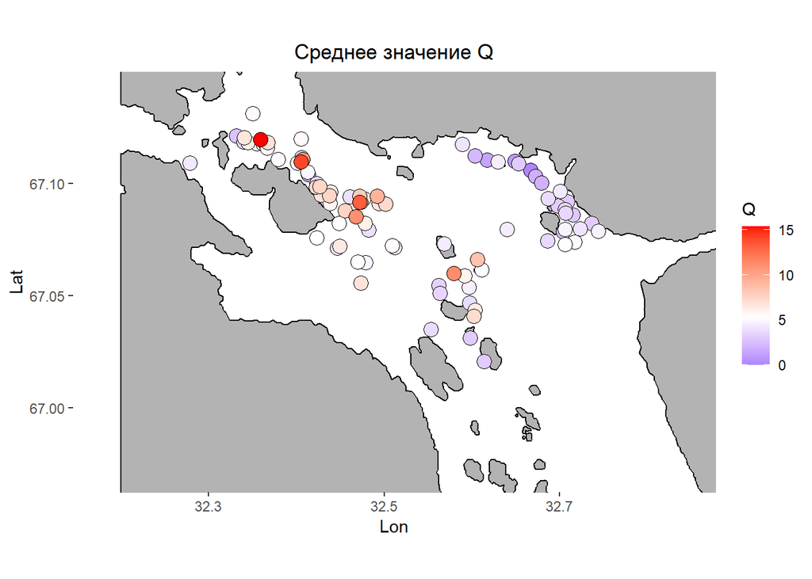

В принципе, на сырых данных виден некоторый паттерн - самая высокая осторожность в районе Оленьего архипелага.

### Модель

Теперь построим модель, в которой будут учтены и другие предикторы.

Плохо, конечно, но в качестве зависимой переменной буду использовать log(Q + 1).

```r
mod <- bam(log(Q +1) ~
             s(Year, k = 6) +
             s(N_eggs, k = 4) +
             s(Log_Area) +
             # s(Dist_to_Mainland, by = Region_3) +
             # s(Dist_to_town, by = Region_3)  +
             te(Lon, Lat, bs = "tp") +
             # Region_2 + регионы коллинеарны расстояниям до материка и до населенных пунктов
             s(Place, k = 87, bs = "re"),
           family = gaussian(),
           data = som_isl_region_joined)
```

### Проверяем валидность модели

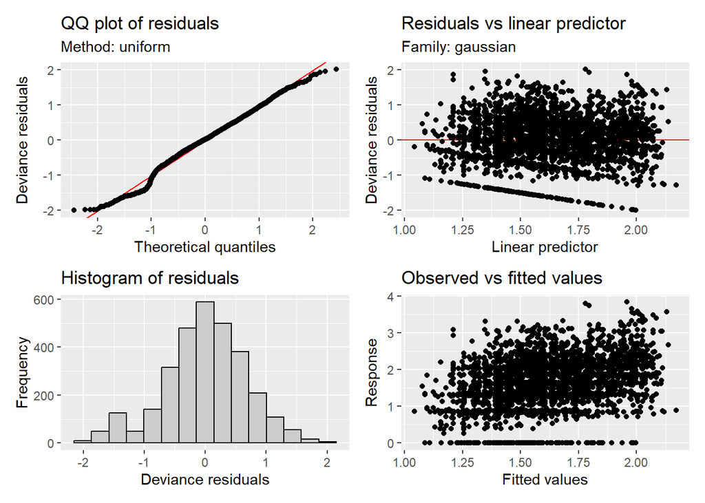

Почти хорошо…. Но есть левый пик в остатках. Это все нули виноваты.

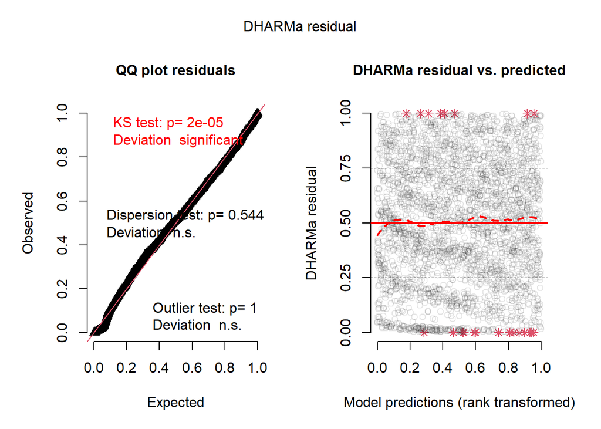

```
## Object of Class DHARMa with simulated residuals based on 250 simulations with refit = FALSE . See ?DHARMa::simulateResiduals for help.
##
## Scaled residual values: 0.852 0.864 0.772 0.828 0.708 0.344 0.384 0.476 0.292 0.2 0.02 0.352 0.46 0.02 0.768 0.368 0.524 0.908 0.92 0.176 ...
```

Диагностика модели все равно плохая, но пока лучшее, что я видел с этим материалом.

Вот summary от этой модели

```
##
## Family: gaussian
## Link function: identity
##
## Formula:
## log(Q + 1) ~ s(Year, k = 6) + s(N_eggs, k = 4) + s(Log_Area) +
##     te(Lon, Lat, bs = "tp") + s(Place, k = 87, bs = "re")
##
## Parametric coefficients:
##             Estimate Std. Error t value Pr(>|t|)
## (Intercept)  1.57945    0.02766   57.11   <2e-16 ***
## ---
## Signif. codes:  0 '***' 0.001 '**' 0.01 '*' 0.05 '.' 0.1 ' ' 1
##
## Approximate significance of smooth terms:
##                edf Ref.df      F  p-value
## s(Year)      2.551  3.138  9.157 4.54e-06 ***
## s(N_eggs)    1.000  1.000 17.368 3.23e-05 ***
## s(Log_Area)  1.000  1.000  5.953   0.0147 *
## te(Lon,Lat)  6.805  7.582  5.921 1.37e-07 ***
## s(Place)    32.145 83.000  0.999  < 2e-16 ***
## ---
## Signif. codes:  0 '***' 0.001 '**' 0.01 '*' 0.05 '.' 0.1 ' ' 1
##
## R-sq.(adj) =  0.103   Deviance explained = 11.6%
## fREML = 3170.2  Scale est. = 0.4599    n = 3032
```

#### Многолетняя динамика

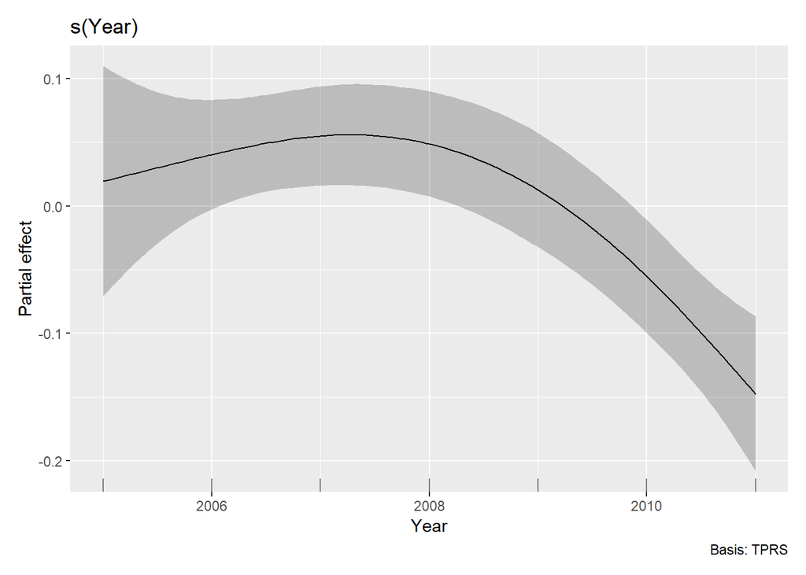

#### Количество яиц

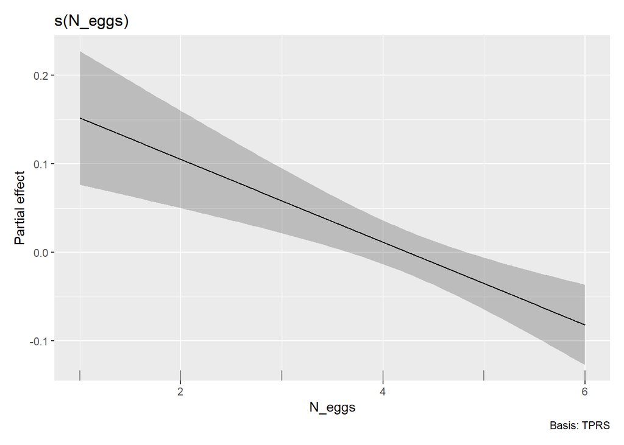

#### Размер острова

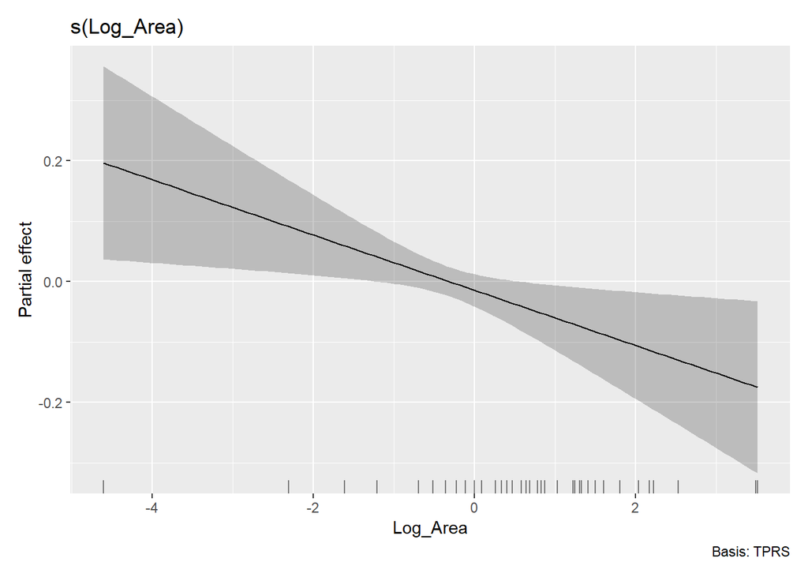

#### Пространственный паттерн

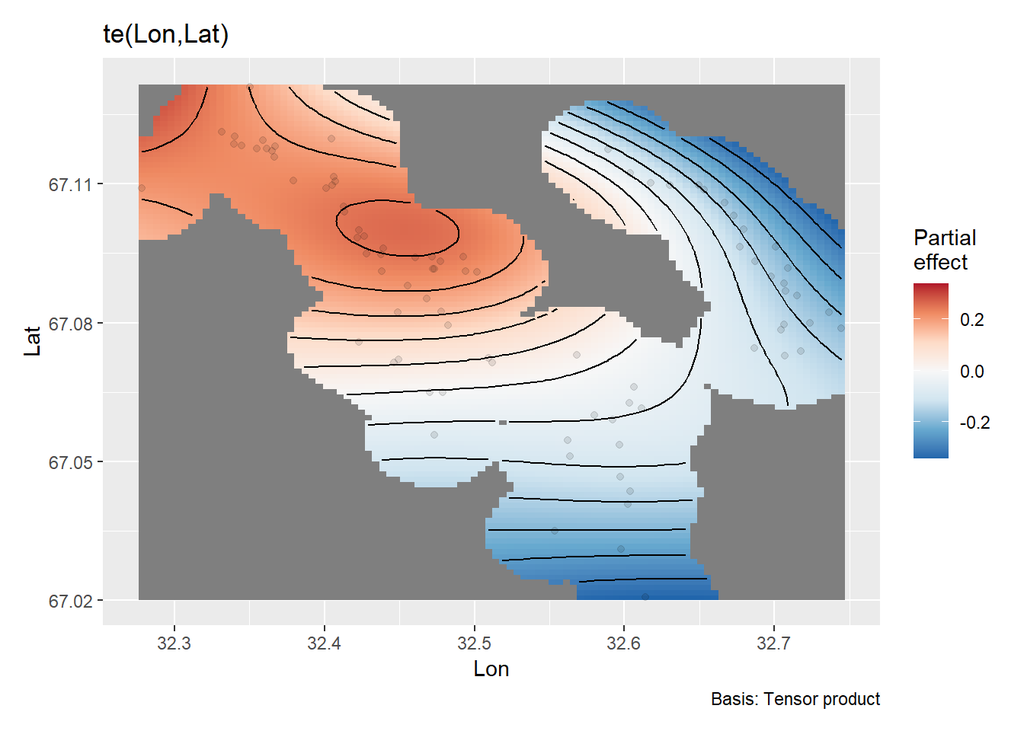

Та же картинка, но с наложенной картой

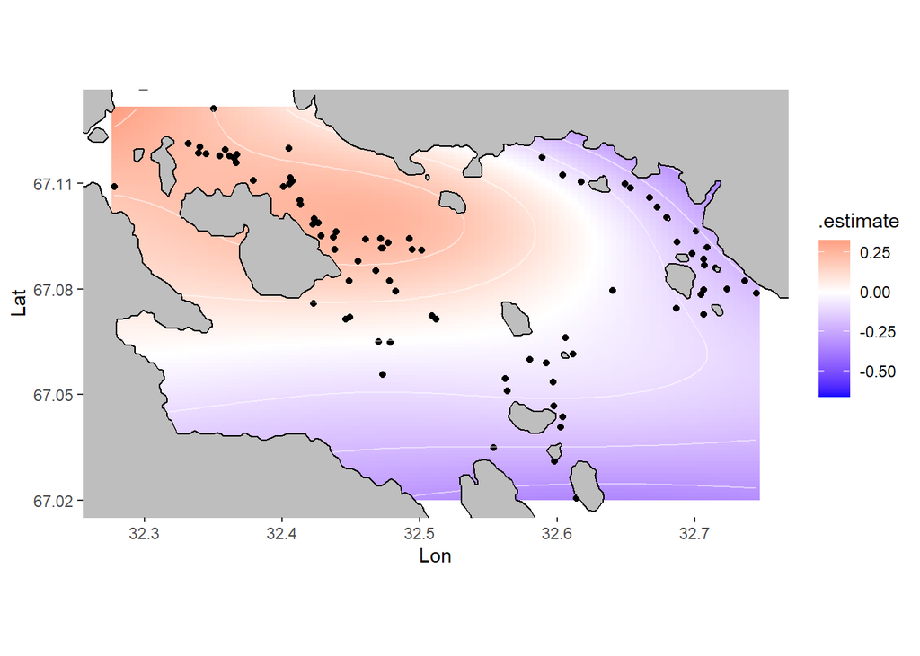

Видно, что модель предсказывает более высокую осторожность в районах, расположенных ближе к Кандалакше.

Тут еще надо поработать, но вот такой вариант модели мне пока нравится больше. То есть мы не включаем в модель всяческие расстояния до (они коррелируют с координатами). Это, конечно, снижает интерпретабельность модели. Однако пространственный выявленный паттерн позволяет говорить о том, что в куту залива они более пугливые. Почему? Может там беспокойства больше?

#### Глянем на остатки модели

Явной Связи остатков с Dist_to_Mainland и Dist_to_town не наблюдается. Это говорит о том, что пространственная модель “вбирает” в себя и эти ипредикторы.

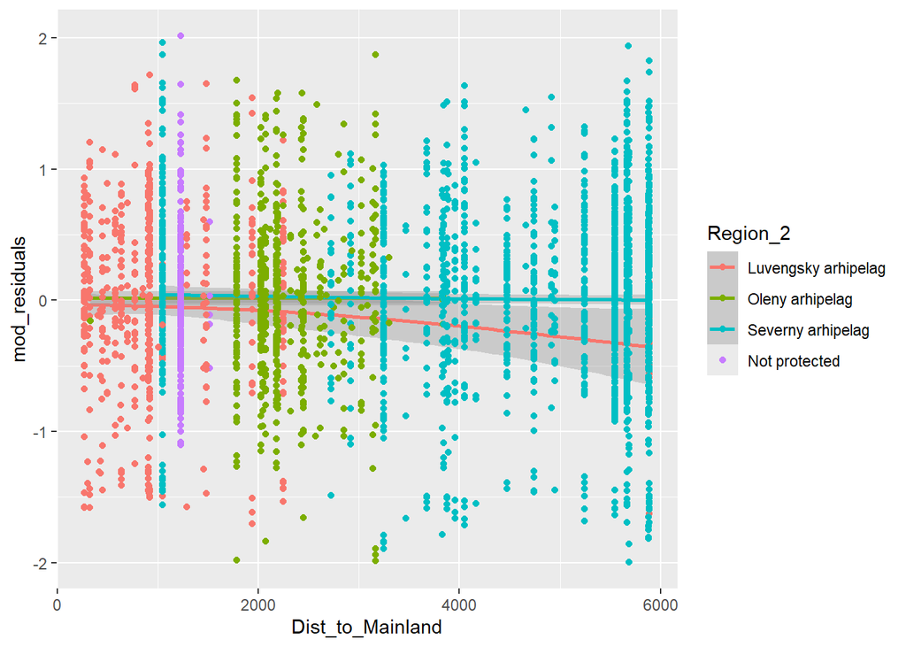

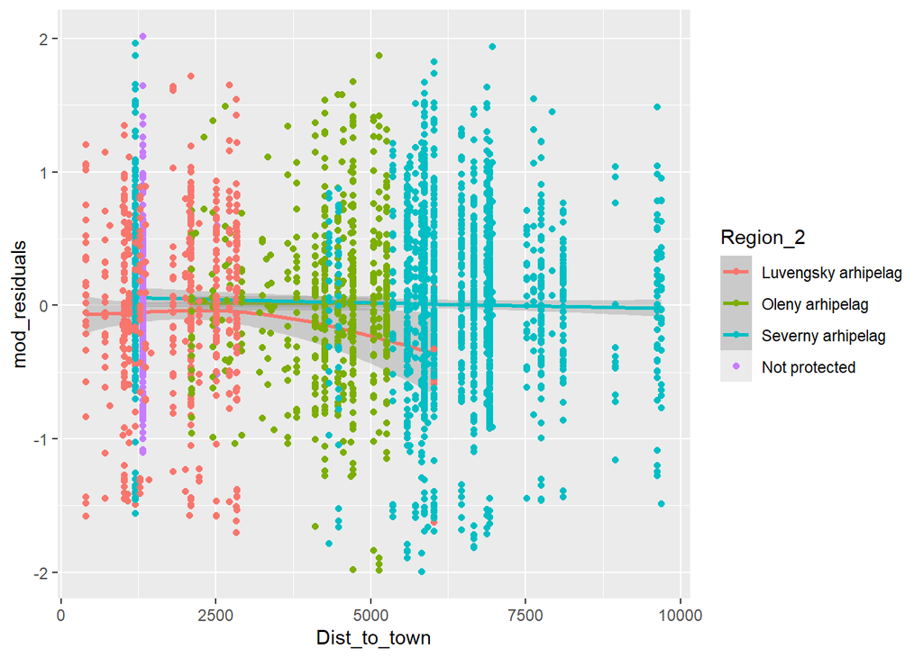

Фактор “Region” тоже ОК, не показывает какого-то паттерна в остатках. То есть модель и это как-то учитывает.

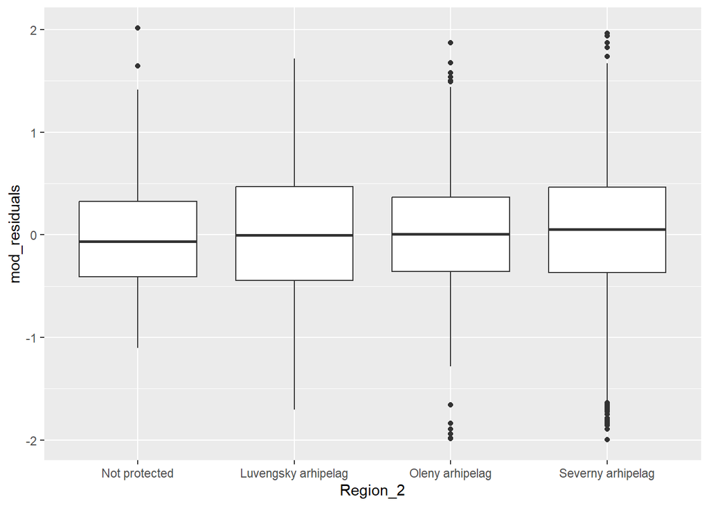